# IS 470 Lab 5: K Nearest Neighbor

This data set contains information of cars purchased at the Auction.  
We will use this file to predict the quality of buying decisions and visualize decision processes.  
VARIABLE DESCRIPTIONS:  
Auction: Auction provider at which the vehicle was purchased  
Color: Vehicle Color  
IsBadBuy: Identifies if the kicked vehicle was an avoidable purchase  
MMRCurrentAuctionAveragePrice: Acquisition price for this vehicle in average condition as of current day  
Size: The size category of the vehicle (Compact, SUV, etc.)  
TopThreeAmericanName:Identifies if the manufacturer is one of the top three American manufacturers  
VehBCost: Acquisition cost paid for the vehicle at time of purchase  
VehicleAge: The Years elapsed since the manufacturer's year  
VehOdo: The vehicles odometer reading  
WarrantyCost: Warranty price (term=36month and millage=36K)  
WheelType: The vehicle wheel type description (Alloy, Covers)  
Target variable: **IsBadBuy**

## 1.Upload and clean data

```python
# Mounting Google Drive
from google.colab import drive
drive.mount('/content/drive')
```

```python
# Import libraries
import pandas as pd
from sklearn.model_selection import train_test_split
from sklearn import preprocessing
from sklearn import tree
from sklearn.tree import DecisionTreeClassifier
from sklearn.neighbors import KNeighborsClassifier
from sklearn.metrics import plot_confusion_matrix
from sklearn.metrics import classification_report
from matplotlib import pyplot as plt
```

```python
# Read data
carAuction = pd.read_csv("/content/drive/MyDrive/IS470_data/carAuction.csv")
carAuction
```

|  | Auction | Color | IsBadBuy | MMRCurrentAuctionAveragePrice | Size | TopThreeAmericanName | VehBCost | VehicleAge | VehOdo | WarrantyCost | WheelType |
| --- | --- | --- | --- | --- | --- | --- | --- | --- | --- | --- | --- |
| 0 | ADESA | WHITE | No | 2871 | LARGE TRUCK | FORD | 5300 | 8 | 75419 | 869 | Alloy |
| 1 | ADESA | GOLD | Yes | 1840 | VAN | FORD | 3600 | 8 | 82944 | 2322 | Alloy |
| 2 | ADESA | RED | No | 8931 | SMALL SUV | CHRYSLER | 7500 | 4 | 57338 | 588 | Alloy |
| 3 | ADESA | GOLD | No | 8320 | CROSSOVER | FORD | 8500 | 5 | 55909 | 1169 | Alloy |
| 4 | ADESA | GREY | No | 11520 | LARGE TRUCK | FORD | 10100 | 5 | 86702 | 853 | Alloy |
| ... | ... | ... | ... | ... | ... | ... | ... | ... | ... | ... | ... |
| 9995 | ADESA | RED | No | 7536 | SMALL SUV | CHRYSLER | 6600 | 4 | 85377 | 983 | Alloy |
| 9996 | ADESA | BLACK | No | 4921 | LARGE TRUCK | GM | 7000 | 7 | 89665 | 1543 | Alloy |
| 9997 | ADESA | BLACK | No | 9263 | MEDIUM SUV | CHRYSLER | 9000 | 4 | 59383 | 1417 | Alloy |
| 9998 | ADESA | BLUE | No | 3240 | MEDIUM | OTHER | 5500 | 4 | 48642 | 482 | Covers |
| 9999 | ADESA | SILVER | No | 6148 | MEDIUM SUV | FORD | 7000 | 5 | 82563 | 1243 | Alloy |

10000 rows × 11 columns

```python
# Show the head rows of a data frame
carAuction.head()
```

|  | Auction | Color | IsBadBuy | MMRCurrentAuctionAveragePrice | Size | TopThreeAmericanName | VehBCost | VehicleAge | VehOdo | WarrantyCost | WheelType |
| --- | --- | --- | --- | --- | --- | --- | --- | --- | --- | --- | --- |
| 0 | ADESA | WHITE | No | 2871 | LARGE TRUCK | FORD | 5300 | 8 | 75419 | 869 | Alloy |
| 1 | ADESA | GOLD | Yes | 1840 | VAN | FORD | 3600 | 8 | 82944 | 2322 | Alloy |
| 2 | ADESA | RED | No | 8931 | SMALL SUV | CHRYSLER | 7500 | 4 | 57338 | 588 | Alloy |
| 3 | ADESA | GOLD | No | 8320 | CROSSOVER | FORD | 8500 | 5 | 55909 | 1169 | Alloy |
| 4 | ADESA | GREY | No | 11520 | LARGE TRUCK | FORD | 10100 | 5 | 86702 | 853 | Alloy |

```python
# Examine variable type
carAuction.dtypes
```

```
Auction                          object
Color                            object
IsBadBuy                         object
MMRCurrentAuctionAveragePrice     int64
Size                             object
TopThreeAmericanName             object
VehBCost                          int64
VehicleAge                        int64
VehOdo                            int64
WarrantyCost                      int64
WheelType                        object
dtype: object
```

```python
# Change categorical variables to "category"
carAuction['Auction'] = carAuction['Auction'].astype('category')
carAuction['Color'] = carAuction['Color'].astype('category')
carAuction['IsBadBuy'] = carAuction['IsBadBuy'].astype('category')
carAuction['Size'] = carAuction['Size'].astype('category')
carAuction['TopThreeAmericanName'] = carAuction['TopThreeAmericanName'].astype('category')
carAuction['WheelType'] = carAuction['WheelType'].astype('category')
```

```python
# Examine variable type
carAuction.dtypes
```

```
Auction                          category
Color                            category
IsBadBuy                         category
MMRCurrentAuctionAveragePrice       int64
Size                             category
TopThreeAmericanName             category
VehBCost                            int64
VehicleAge                          int64
VehOdo                              int64
WarrantyCost                        int64
WheelType                        category
dtype: object
```

## 2.Partition the data set for K Nearest Neighbor model

```python
# Create dummy variables
carAuction = pd.get_dummies(carAuction, columns=['Auction','Color','Size','TopThreeAmericanName','WheelType'], drop_first=True)
carAuction
```

|  | IsBadBuy | MMRCurrentAuctionAveragePrice | VehBCost | VehicleAge | VehOdo | WarrantyCost | Auction_MANHEIM | Auction_OTHER | Color_BLACK | Color_BLUE | Color_BROWN | Color_GOLD | Color_GREEN | Color_GREY | Color_MAROON | Color_NOT AVAIL | Color_ORANGE | Color_OTHER | Color_PURPLE | Color_RED | Color_SILVER | Color_WHITE | Color_YELLOW | Size_CROSSOVER | Size_LARGE | Size_LARGE SUV | Size_LARGE TRUCK | Size_MEDIUM | Size_MEDIUM SUV | … |
| --- | --- | --- | --- | --- | --- | --- | --- | --- | --- | --- | --- | --- | --- | --- | --- | --- | --- | --- | --- | --- | --- | --- | --- | --- | --- | --- | --- | --- | --- | --- |
| 0 | No | 2871 | 5300 | 8 | 75419 | 869 | 0 | 0 | 0 | 0 | 0 | 0 | 0 | 0 | 0 | 0 | 0 | 0 | 0 | 0 | 0 | 1 | 0 | 0 | 0 | 0 | 1 | 0 | 0 | … |
| 1 | Yes | 1840 | 3600 | 8 | 82944 | 2322 | 0 | 0 | 0 | 0 | 0 | 1 | 0 | 0 | 0 | 0 | 0 | 0 | 0 | 0 | 0 | 0 | 0 | 0 | 0 | 0 | 0 | 0 | 0 | … |
| 2 | No | 8931 | 7500 | 4 | 57338 | 588 | 0 | 0 | 0 | 0 | 0 | 0 | 0 | 0 | 0 | 0 | 0 | 0 | 0 | 1 | 0 | 0 | 0 | 0 | 0 | 0 | 0 | 0 | 0 | … |
| 3 | No | 8320 | 8500 | 5 | 55909 | 1169 | 0 | 0 | 0 | 0 | 0 | 1 | 0 | 0 | 0 | 0 | 0 | 0 | 0 | 0 | 0 | 0 | 0 | 1 | 0 | 0 | 0 | 0 | 0 | … |
| 4 | No | 11520 | 10100 | 5 | 86702 | 853 | 0 | 0 | 0 | 0 | 0 | 0 | 0 | 1 | 0 | 0 | 0 | 0 | 0 | 0 | 0 | 0 | 0 | 0 | 0 | 0 | 1 | 0 | 0 | … |
| ... | ... | ... | ... | ... | ... | ... | ... | ... | ... | ... | ... | ... | ... | ... | ... | ... | ... | ... | ... | ... | ... | ... | ... | ... | ... | ... | ... | ... | ... | … |
| 9995 | No | 7536 | 6600 | 4 | 85377 | 983 | 0 | 0 | 0 | 0 | 0 | 0 | 0 | 0 | 0 | 0 | 0 | 0 | 0 | 1 | 0 | 0 | 0 | 0 | 0 | 0 | 0 | 0 | 0 | … |
| 9996 | No | 4921 | 7000 | 7 | 89665 | 1543 | 0 | 0 | 1 | 0 | 0 | 0 | 0 | 0 | 0 | 0 | 0 | 0 | 0 | 0 | 0 | 0 | 0 | 0 | 0 | 0 | 1 | 0 | 0 | … |
| 9997 | No | 9263 | 9000 | 4 | 59383 | 1417 | 0 | 0 | 1 | 0 | 0 | 0 | 0 | 0 | 0 | 0 | 0 | 0 | 0 | 0 | 0 | 0 | 0 | 0 | 0 | 0 | 0 | 0 | 1 | … |
| 9998 | No | 3240 | 5500 | 4 | 48642 | 482 | 0 | 0 | 0 | 1 | 0 | 0 | 0 | 0 | 0 | 0 | 0 | 0 | 0 | 0 | 0 | 0 | 0 | 0 | 0 | 0 | 0 | 1 | 0 | … |
| 9999 | No | 6148 | 7000 | 5 | 82563 | 1243 | 0 | 0 | 0 | 0 | 0 | 0 | 0 | 0 | 0 | 0 | 0 | 0 | 0 | 0 | 1 | 0 | 0 | 0 | 0 | 0 | 0 | 0 | 1 | … |

10000 rows × 40 columns

```python
target = carAuction['IsBadBuy']
predictors = carAuction.drop(['IsBadBuy'],axis=1)
# Apply minmax normalization on predictors
min_max_scalar = preprocessing.MinMaxScaler()
predictors_normalized = pd.DataFrame(min_max_scalar.fit_transform(predictors))
predictors_normalized.columns = predictors.columns
predictors_normalized
```

|  | MMRCurrentAuctionAveragePrice | VehBCost | VehicleAge | VehOdo | WarrantyCost | Auction_MANHEIM | Auction_OTHER | Color_BLACK | Color_BLUE | Color_BROWN | Color_GOLD | Color_GREEN | Color_GREY | Color_MAROON | Color_NOT AVAIL | Color_ORANGE | Color_OTHER | Color_PURPLE | Color_RED | Color_SILVER | Color_WHITE | Color_YELLOW | Size_CROSSOVER | Size_LARGE | Size_LARGE SUV | Size_LARGE TRUCK | Size_MEDIUM | Size_MEDIUM SUV | Size_SMALL SUV | … |
| --- | --- | --- | --- | --- | --- | --- | --- | --- | --- | --- | --- | --- | --- | --- | --- | --- | --- | --- | --- | --- | --- | --- | --- | --- | --- | --- | --- | --- | --- | --- |
| 0 | 0.104237 | 0.171627 | 0.875 | 0.672907 | 0.074665 | 0.0 | 0.0 | 0.0 | 0.0 | 0.0 | 0.0 | 0.0 | 0.0 | 0.0 | 0.0 | 0.0 | 0.0 | 0.0 | 0.0 | 0.0 | 1.0 | 0.0 | 0.0 | 0.0 | 0.0 | 1.0 | 0.0 | 0.0 | 0.0 | … |
| 1 | 0.066805 | 0.114136 | 0.875 | 0.744636 | 0.341222 | 0.0 | 0.0 | 0.0 | 0.0 | 0.0 | 1.0 | 0.0 | 0.0 | 0.0 | 0.0 | 0.0 | 0.0 | 0.0 | 0.0 | 0.0 | 0.0 | 0.0 | 0.0 | 0.0 | 0.0 | 0.0 | 0.0 | 0.0 | 0.0 | … |
| 2 | 0.324257 | 0.246026 | 0.375 | 0.500558 | 0.023115 | 0.0 | 0.0 | 0.0 | 0.0 | 0.0 | 0.0 | 0.0 | 0.0 | 0.0 | 0.0 | 0.0 | 0.0 | 0.0 | 1.0 | 0.0 | 0.0 | 0.0 | 0.0 | 0.0 | 0.0 | 0.0 | 0.0 | 0.0 | 1.0 | … |
| 3 | 0.302073 | 0.279844 | 0.500 | 0.486936 | 0.129701 | 0.0 | 0.0 | 0.0 | 0.0 | 0.0 | 1.0 | 0.0 | 0.0 | 0.0 | 0.0 | 0.0 | 0.0 | 0.0 | 0.0 | 0.0 | 0.0 | 0.0 | 1.0 | 0.0 | 0.0 | 0.0 | 0.0 | 0.0 | 0.0 | … |
| 4 | 0.418255 | 0.333953 | 0.500 | 0.780457 | 0.071730 | 0.0 | 0.0 | 0.0 | 0.0 | 0.0 | 0.0 | 0.0 | 1.0 | 0.0 | 0.0 | 0.0 | 0.0 | 0.0 | 0.0 | 0.0 | 0.0 | 0.0 | 0.0 | 0.0 | 0.0 | 1.0 | 0.0 | 0.0 | 0.0 | … |
| ... | ... | ... | ... | ... | ... | ... | ... | ... | ... | ... | ... | ... | ... | ... | ... | ... | ... | ... | ... | ... | ... | ... | ... | ... | ... | ... | ... | ... | ... | … |
| 9995 | 0.273609 | 0.215590 | 0.375 | 0.767827 | 0.095579 | 0.0 | 0.0 | 0.0 | 0.0 | 0.0 | 0.0 | 0.0 | 0.0 | 0.0 | 0.0 | 0.0 | 0.0 | 0.0 | 1.0 | 0.0 | 0.0 | 0.0 | 0.0 | 0.0 | 0.0 | 0.0 | 0.0 | 0.0 | 1.0 | … |
| 9996 | 0.178666 | 0.229117 | 0.750 | 0.808701 | 0.198312 | 0.0 | 0.0 | 1.0 | 0.0 | 0.0 | 0.0 | 0.0 | 0.0 | 0.0 | 0.0 | 0.0 | 0.0 | 0.0 | 0.0 | 0.0 | 0.0 | 0.0 | 0.0 | 0.0 | 0.0 | 1.0 | 0.0 | 0.0 | 0.0 | … |
| 9997 | 0.336310 | 0.296753 | 0.375 | 0.520051 | 0.175197 | 0.0 | 0.0 | 1.0 | 0.0 | 0.0 | 0.0 | 0.0 | 0.0 | 0.0 | 0.0 | 0.0 | 0.0 | 0.0 | 0.0 | 0.0 | 0.0 | 0.0 | 0.0 | 0.0 | 0.0 | 0.0 | 0.0 | 1.0 | 0.0 | … |
| 9998 | 0.117634 | 0.178390 | 0.375 | 0.417667 | 0.003669 | 0.0 | 0.0 | 0.0 | 1.0 | 0.0 | 0.0 | 0.0 | 0.0 | 0.0 | 0.0 | 0.0 | 0.0 | 0.0 | 0.0 | 0.0 | 0.0 | 0.0 | 0.0 | 0.0 | 0.0 | 0.0 | 1.0 | 0.0 | 0.0 | … |
| 9999 | 0.223215 | 0.229117 | 0.500 | 0.741004 | 0.143276 | 0.0 | 0.0 | 0.0 | 0.0 | 0.0 | 0.0 | 0.0 | 0.0 | 0.0 | 0.0 | 0.0 | 0.0 | 0.0 | 0.0 | 1.0 | 0.0 | 0.0 | 0.0 | 0.0 | 0.0 | 0.0 | 0.0 | 1.0 | 0.0 | … |

10000 rows × 39 columns

```python
# Partition the data
predictors_train, predictors_test, target_train, target_test = train_test_split(predictors_normalized, target, test_size=0.3, random_state=0)
print(predictors_train.shape, predictors_test.shape, target_train.shape, target_test.shape)
```

```
(7000, 39) (3000, 39) (7000,) (3000,)
```

```python
# Examine the porportion of target variable for training data set
print(target_train.value_counts(normalize=True))
```

```
No     0.869571
Yes    0.130429
Name: IsBadBuy, dtype: float64
```

```python
# Examine the porportion of target variable for testing data set
print(target_test.value_counts(normalize=True))
```

```
No     0.872667
Yes    0.127333
Name: IsBadBuy, dtype: float64
```

## 3.K Nearest Neighbor model prediction

### Build a K Nearest Neighbor model with n_neighbors = 1

```python
# Build a K Nearest Neighbor model on training data with n_neighbors = 1
model1 = KNeighborsClassifier(n_neighbors=1)
model1.fit(predictors_train, target_train)
```

```
KNeighborsClassifier(n_neighbors=1)
```

```python
# Make predictions on training and testing data
prediction_on_train = model1.predict(predictors_train)
prediction_on_test = model1.predict(predictors_test)
```

```
<sklearn.metrics._plot.confusion_matrix.ConfusionMatrixDisplay at 0x7fca107abad0>
```

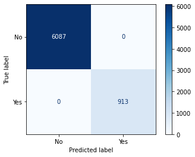

```python
# Examine the evaluation results on training data: confusion_matrix
plot_confusion_matrix(model1, predictors_train, target_train, cmap=plt.cm.Blues, values_format='d')
```

```python
# Examine the evaluation results on training data: accuracy, precision, recall, and f1-score
print(classification_report(target_train, prediction_on_train))
```

```
              precision    recall  f1-score   support

          No       1.00      1.00      1.00      6087
         Yes       1.00      1.00      1.00       913

    accuracy                           1.00      7000
   macro avg       1.00      1.00      1.00      7000
weighted avg       1.00      1.00      1.00      7000
```

```
<sklearn.metrics._plot.confusion_matrix.ConfusionMatrixDisplay at 0x7fca1079dfd0>
```

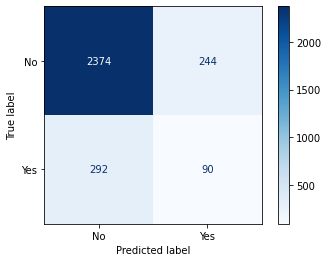

```python
# Examine the evaluation results on testing data: confusion_matrix
plot_confusion_matrix(model1, predictors_test, target_test, cmap=plt.cm.Blues, values_format='d')
```

```python
# Examine the evaluation results on testing data: accuracy, precision, recall, and f1-score
print(classification_report(target_test, prediction_on_test))
```

```
              precision    recall  f1-score   support

          No       0.89      0.91      0.90      2618
         Yes       0.27      0.24      0.25       382

    accuracy                           0.82      3000
   macro avg       0.58      0.57      0.57      3000
weighted avg       0.81      0.82      0.82      3000
```

Q1. Compare the performances on training and testing sets

a. Why we have perfect evaluation results on the training data?  
Because n_neighbors = 1 (use its own value to make prediction for itself).

b. Does the KNN model with n_neighbors = 1 generalize well on the testing set? why?  
No. Because it overfit (big gap between training and testing accuracy).

### Build a K Nearest Neighbor model with n_neighbors = 3

```python
# Build a K Nearest Neighbor model on training data with n_neighbors = 3
model2 = KNeighborsClassifier(n_neighbors=3)
model2.fit(predictors_train, target_train)
```

```
KNeighborsClassifier(n_neighbors=3)
```

```python
# Make predictions on training and testing data
prediction_on_train = model2.predict(predictors_train)
prediction_on_test = model2.predict(predictors_test)
```

```
<sklearn.metrics._plot.confusion_matrix.ConfusionMatrixDisplay at 0x7fca12ede690>
```

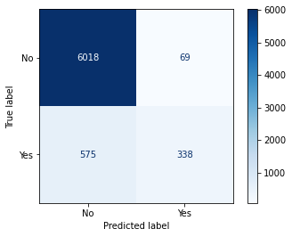

```python
# Examine the evaluation results on training data: confusion_matrix
plot_confusion_matrix(model2, predictors_train, target_train, cmap=plt.cm.Blues, values_format='d')
```

```python
# Examine the evaluation results on training data: accuracy, precision, recall, and f1-score
print(classification_report(target_train, prediction_on_train))
```

```
              precision    recall  f1-score   support

          No       0.91      0.99      0.95      6087
         Yes       0.83      0.37      0.51       913

    accuracy                           0.91      7000
   macro avg       0.87      0.68      0.73      7000
weighted avg       0.90      0.91      0.89      7000
```

```
<sklearn.metrics._plot.confusion_matrix.ConfusionMatrixDisplay at 0x7fca10988450>
```

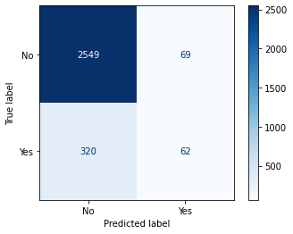

```python
# Examine the evaluation results on testing data: confusion_matrix
plot_confusion_matrix(model2, predictors_test, target_test, cmap=plt.cm.Blues, values_format='d')
```

```python
# Examine the evaluation results on testing data: accuracy, precision, recall, and f1-score
print(classification_report(target_test, prediction_on_test))
```

```
              precision    recall  f1-score   support

          No       0.89      0.97      0.93      2618
         Yes       0.47      0.16      0.24       382

    accuracy                           0.87      3000
   macro avg       0.68      0.57      0.59      3000
weighted avg       0.84      0.87      0.84      3000
```

### Build a K Nearest Neighbor model with n_neighbors = 10

```python
# Build a K Nearest Neighbor model on training data with n_neighbors = 10
model3 = KNeighborsClassifier(n_neighbors=10)
model3.fit(predictors_train, target_train)
```

```
KNeighborsClassifier(n_neighbors=10)
```

```python
# Make predictions on training and testing data
prediction_on_train = model3.predict(predictors_train)
prediction_on_test = model3.predict(predictors_test)
```

```
<sklearn.metrics._plot.confusion_matrix.ConfusionMatrixDisplay at 0x7fca1069c850>
```

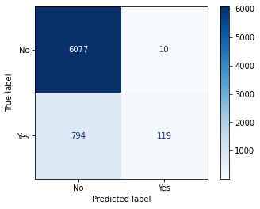

```python
# Examine the evaluation results on training data: confusion_matrix
plot_confusion_matrix(model3, predictors_train, target_train, cmap=plt.cm.Blues, values_format='d')
```

```python
# Examine the evaluation results on training data: accuracy, precision, recall, and f1-score
print(classification_report(target_train, prediction_on_train))
```

```
              precision    recall  f1-score   support

          No       0.88      1.00      0.94      6087
         Yes       0.92      0.13      0.23       913

    accuracy                           0.89      7000
   macro avg       0.90      0.56      0.58      7000
weighted avg       0.89      0.89      0.85      7000
```

```
<sklearn.metrics._plot.confusion_matrix.ConfusionMatrixDisplay at 0x7fca10891a50>
```

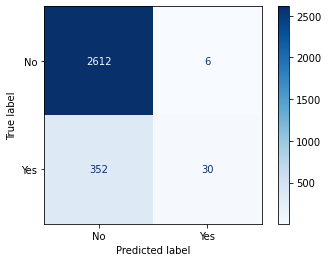

```python
# Examine the evaluation results on testing data: confusion_matrix
plot_confusion_matrix(model3, predictors_test, target_test, cmap=plt.cm.Blues, values_format='d')
```

```python
# Examine the evaluation results on testing data: accuracy, precision, recall, and f1-score
print(classification_report(target_test, prediction_on_test))
```

```
              precision    recall  f1-score   support

          No       0.88      1.00      0.94      2618
         Yes       0.83      0.08      0.14       382

    accuracy                           0.88      3000
   macro avg       0.86      0.54      0.54      3000
weighted avg       0.88      0.88      0.83      3000
```

Q2. Which KNN model is the best for identifying bad buy cars (n_neighbors=1, 3 or 10)? and why?  
KNN model with n_neighbors=1 because 'Yes' recall value on testing data of model1 is 0.24 which is the highest among the 3 models.

Q3. Compare the performances on the training and testing data with n_neighbors = 1, 3, and 10. How the KNN model performs as we increase the value of n_neighbors?  
As we increase the value of n_neighbors, the model performs better and smaller gap between training and testing data.

## 4.Generalization and Overfitting

### Build a decision tree model with max_depth = 1

```python
# Build a decision tree model on training data with max_depth = 1
model_tree1 = DecisionTreeClassifier(criterion = "entropy", random_state = 1, max_depth = 1)
model_tree1.fit(predictors_train, target_train)
```

```
DecisionTreeClassifier(criterion='entropy', max_depth=1, random_state=1)
```

```
[Text(0.5, 0.75, 'WheelType_unkwnWheel <= 0.5\nentropy = 0.559\nsamples = 7000\nvalue = [6087, 913]\nclass = No'),
```

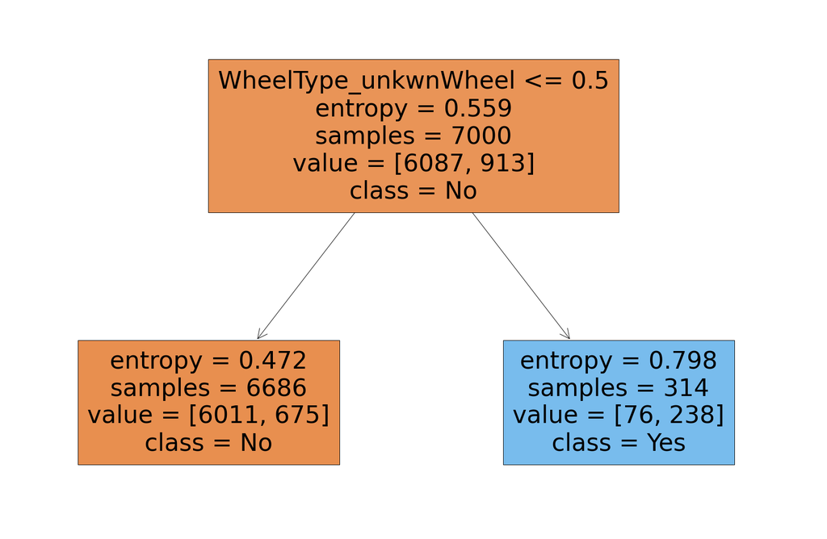

```python
# Plot the tree
fig = plt.figure(figsize=(30,20))
tree.plot_tree(model_tree1,
               feature_names=list(carAuction.columns)[1:],
               class_names=['No','Yes'],
               filled=True)
```

```python
# Make predictions on training and testing data
prediction_on_train = model_tree1.predict(predictors_train)
prediction_on_test = model_tree1.predict(predictors_test)
```

```python
# Examine the evaluation results on training data: accuracy, precision, recall, and f1-score
print(classification_report(target_train, prediction_on_train))
```

```
              precision    recall  f1-score   support

          No       0.90      0.99      0.94      6087
         Yes       0.76      0.26      0.39       913

    accuracy                           0.89      7000
   macro avg       0.83      0.62      0.66      7000
weighted avg       0.88      0.89      0.87      7000
```

```python
# Examine the evaluation results on testing data: accuracy, precision, recall, and f1-score
print(classification_report(target_test, prediction_on_test))
```

```
              precision    recall  f1-score   support

          No       0.90      0.99      0.94      2618
         Yes       0.76      0.26      0.39       382

    accuracy                           0.90      3000
   macro avg       0.83      0.62      0.67      3000
weighted avg       0.88      0.90      0.87      3000
```

### Build a decision tree model with max_depth = 2

```python
# Build a decision tree model on training data with max_depth = 2
model_tree2 = DecisionTreeClassifier(criterion = "entropy", random_state = 1, max_depth = 2)
model_tree2.fit(predictors_train, target_train)
```

```
DecisionTreeClassifier(criterion='entropy', max_depth=2, random_state=1)
```

```
[Text(0.5, 0.8333333333333334, 'WheelType_unkwnWheel <= 0.5\nentropy = 0.559\nsamples = 7000\nvalue = [6087, 913]\nclass = No'),
```

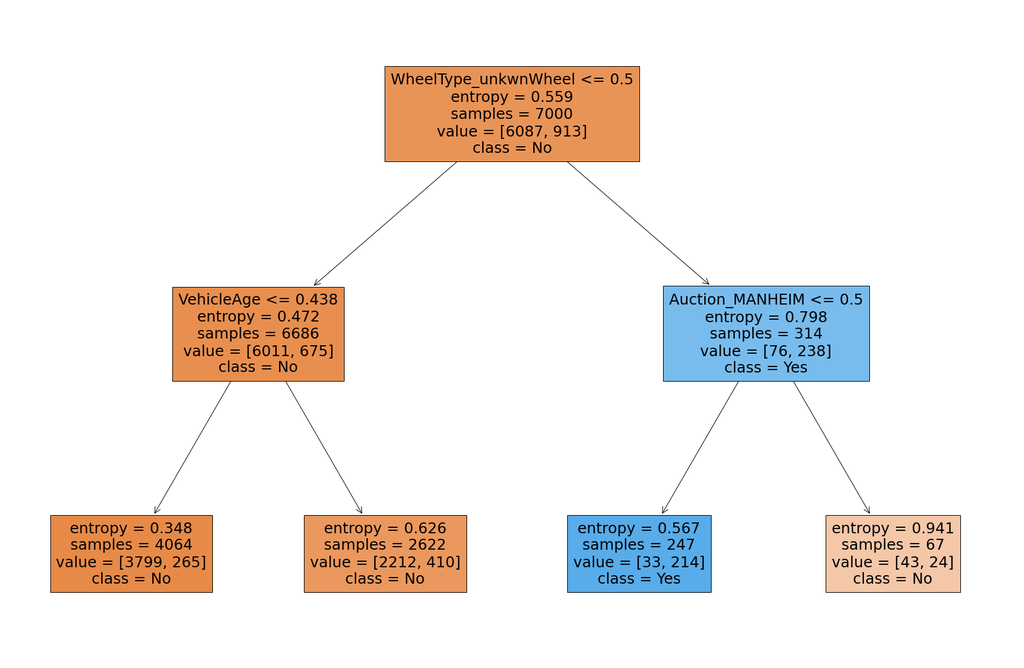

```python
# Plot the tree
fig = plt.figure(figsize=(30,20))
tree.plot_tree(model_tree2,
               feature_names=list(carAuction.columns)[1:],
               class_names=['No','Yes'],
               filled=True)
```

```python
# Make predictions on training and testing data
prediction_on_train = model_tree2.predict(predictors_train)
prediction_on_test = model_tree2.predict(predictors_test)
```

```python
# Examine the evaluation results on training data: accuracy, precision, recall, and f1-score
print(classification_report(target_train, prediction_on_train))
```

```
              precision    recall  f1-score   support

          No       0.90      0.99      0.94      6087
         Yes       0.87      0.23      0.37       913

    accuracy                           0.90      7000
   macro avg       0.88      0.61      0.66      7000
weighted avg       0.89      0.90      0.87      7000
```

```python
# Examine the evaluation results on testing data: accuracy, precision, recall, and f1-score
print(classification_report(target_test, prediction_on_test))
```

```
              precision    recall  f1-score   support

          No       0.90      1.00      0.94      2618
         Yes       0.90      0.22      0.36       382

    accuracy                           0.90      3000
   macro avg       0.90      0.61      0.65      3000
weighted avg       0.90      0.90      0.87      3000
```

### Build a decision tree model with max_depth = 10

```python
# Build a decision tree model on training data with max_depth = 1
model_tree3 = DecisionTreeClassifier(criterion = "entropy", random_state = 1, max_depth = 10)
model_tree3.fit(predictors_train, target_train)
```

```
DecisionTreeClassifier(criterion='entropy', max_depth=10, random_state=1)
```

```
[Text(0.648342803030303, 0.9545454545454546, 'WheelType_unkwnWheel <= 0.5\nentropy = 0.559\nsamples = 7000\nvalue = [6087, 913]\nclass = No'),
```

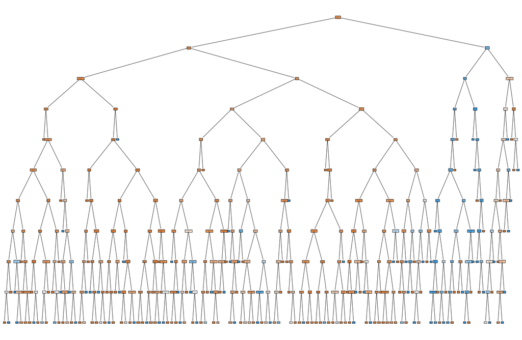

```python
# Plot the tree
fig = plt.figure(figsize=(30,20))
tree.plot_tree(model_tree3,
               feature_names=list(carAuction.columns)[1:],
               class_names=['No','Yes'],
               filled=True)
```

```python
# Make predictions on training and testing data
prediction_on_train = model_tree3.predict(predictors_train)
prediction_on_test = model_tree3.predict(predictors_test)
```

```python
# Examine the evaluation results on training data: accuracy, precision, recall, and f1-score
print(classification_report(target_train, prediction_on_train))
```

```
              precision    recall  f1-score   support

          No       0.92      1.00      0.96      6087
         Yes       0.94      0.41      0.57       913

    accuracy                           0.92      7000
   macro avg       0.93      0.70      0.76      7000
weighted avg       0.92      0.92      0.90      7000
```

```python
# Examine the evaluation results on testing data: accuracy, precision, recall, and f1-score
print(classification_report(target_test, prediction_on_test))
```

```
              precision    recall  f1-score   support

          No       0.90      0.97      0.93      2618
         Yes       0.56      0.25      0.35       382

    accuracy                           0.88      3000
   macro avg       0.73      0.61      0.64      3000
weighted avg       0.86      0.88      0.86      3000
```

Q4. Which decision tree model has the best overall performance on IsBadBuy=Yes class?  
The tree with max_depth = 1 with 'Yes' f1-score = 0.39 which is the highest among other models.

```python
!jupyter nbconvert --to html "/content/drive/MyDrive/IS470_lab/IS470_lab5.ipynb"
```

[output not shown]

[output cut: 75 more lines]

[output not shown]